# Statistical Inference: Course Project 1

VALAT Didier

13/06/2015

## Overview

The aim of this project is to investigate the exponential distribution in R and compare it with the Central Limit Theorem. The exponential distribution can be simulated in R with rexp(n, $\lambda$) where $\lambda$ is the rate parameter. The mean of exponential distribution is 1/$\lambda$ and the standard deviation is also 1/$\lambda$. The variable $\lambda$ will be set to **0.2** for all of the simulations. We will investigate the distribution of averages of 40 exponentials. Note that we will produce a thousand simulations.

## Simulations

First, we will load the required libraries and define the figures size:

```r
# Load libraries
library(knitr)
library(ggplot2)
opts_chunk$set(fig.width=6, fig.height=3.5)
```

Then, we will define the variables for the study:

```r
lambda <- 0.2 # Set lambda for the Exponential Distribution
n <- 40 # Set the number of exponentials
num_of_simul <- 1000 # Set the number of simulations
set.seed(3) # Set the seed for analysis reproducibility
```

After that, we will calculate the Exponential distribution:

```r
# Calculate the Exponential distribution using a Matrix of n * number of simulations
exp_distrib <- matrix(data = rexp(n * num_of_simul, lambda), nrow = num_of_simul)
exp_distrib_mean <- data.frame(means = apply(exp_distrib, 1, mean))
```

And then, we will plot it:

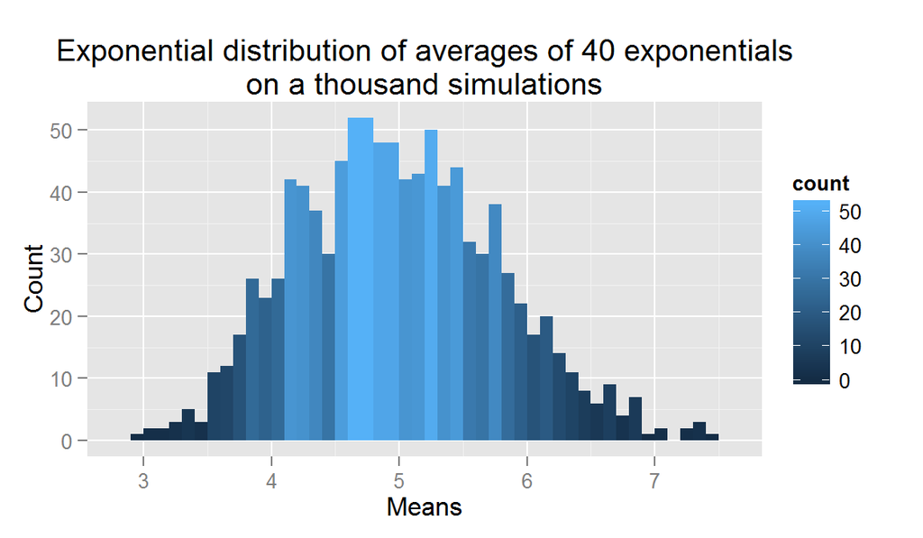

## Sample Mean versus Theoretical Mean

We will calculate the expected mean $\mu$ of an exponential distribution of rate $\lambda$ using the following formula $\mu=\frac{1}{\lambda}$

```r
mu <- 1/lambda
mu
```

```
## [1] 5
```

Next, we will get $\bar X$ which is the average sample mean of 1000 simulations of 40 randomly sampled exponential distributions:

```r
x_bar <- mean(exp_distrib_mean$means)
x_bar
```

```
## [1] 4.98662
```

We can see here that the expected mean and the average sample mean values are very close.

## Sample Variance versus Theoretical Variance

We will now calculate the expected standard deviation $\sigma$ of an Exponential distribution of rate $\lambda$ with the following formula $\sigma=\frac{1/\lambda}{\sqrt{n}}$

```r
std_dev <- 1/lambda/sqrt(n)
std_dev
```

```
## [1] 0.7905694
```

Next, we will get the variance $Var$ of the standard deviation $\sigma$ which is $Var=\sigma^2$

```r
var <- std_dev^2
var
```

```
## [1] 0.625
```

After that, we will calculate the standard deviation $\sigma_x$ and the variance $Var_x$ of the average sample mean of 1000 simulations of 40 randomly sampled exponential distribution:

```r
std_dev_x <- sd(exp_distrib_mean$means)
std_dev_x
```

```
## [1] 0.7910484
```

```r
var_x <- var(exp_distrib_mean$means)
var_x
```

```
## [1] 0.6257575
```

We can note here that the standard deviations are close too. Indeed, the variance is the square of the standard deviations so the values are quite close.

## Distribution

In this last part, we will compare the population means and standard deviation (**blue dashed lines**) with a normal distribution (**red lines**) of the expected values. Lines will be added in order to display the calculated and expected means:

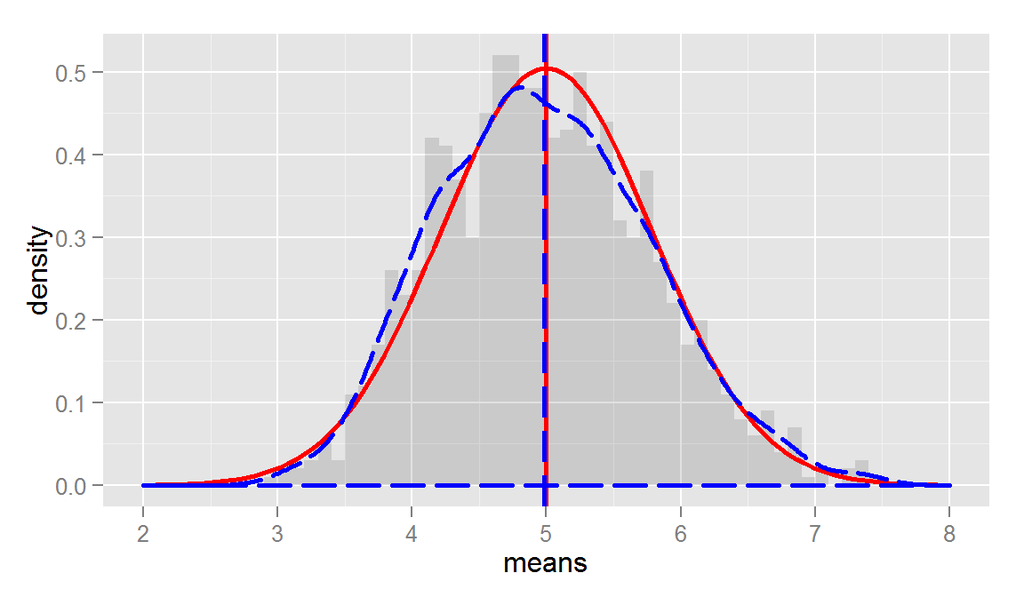

As we can see, the calculated distribution of means of random sampled exponantial distributions quite overlaps with the normal distribution with the expected values based on the given $\lambda$.